# Assignment 1: Principal Component Analysis (PCA) and Probabilistic PCA using Python

# or,

## Step 1b: Normalize the data - the "elbow-grease" way

### -Subtract respective mean from each element of X

### -Divide by standard deviation

### i. Calculate mean vector for each variable of X matrix

(hint: we'll have to calculate 2 means, since D = 2, and we're calculating the row mean) Generally the DxN matrix mean should be a 2x1 array, but in order to subtract the (feature or row here) mean from the dataset at once, we can create a matrix, DxN, with repetitive values in each row, which will correspond to the mean for each feature.

```python
import numpy as np
# To calculate mean vector for each row we need 3 things:

# 1. CREATE A VECTOR that holds all elements of each row
#    NOTE: Using transpose since X.shape = (1000,2).
#    If left like this, we should calculate times 1000, mean vectors with 2 elements (not fun)
#    Taking advantage of linalg to simplify our task at hand.

row1 = X.T[0]
row2 = X.T[1]


# 2. Find the SUM of all elements in the  row vector &
# 3. DEVIDE by the number of elements in the vector. SInce the array is 1-D, vector.size will do.
mean_row1 = np.sum(row1)/row1.size
mean_row2 = np.sum(row2)/row2.size

# Creating the mean vector of X:
mean_vector = np.mat([mean_row1, mean_row2]).T
```

```python
# Let us print the mean vector:

mean_vector

# Since our data looked already centered to zero,
# we expected sth like this; the probability that the value would be EXACTLY 0 tends to p(mean = 0) = 0,
# practically impossible (can also understand that the integral would be just a line, which equls to virtually none surface)
# thus we consider 0.00sth ~ 0 and ok
```

```
matrix([[-0.0017647 ],
        [-0.00096081]])
```

### ii. Create a mean matrix, with shape (2,1000)

##### -for substracting the mean from each element of X

##### -for creating the standard deviation matrix later, needed for the dividing step (if )

##### stdev= {Sum[(x - mean)exp2 /N] }exp1/2

```python
mean_MATRIX = np.kron(np.ones((1,1000)),mean_vector)
```

```python
mean_MATRIX.shape
```

```
(2, 1000)
```

```python
# Let's take a look of the created mean_MATRIX to check if it has been calculated correctly:
mean_MATRIX

#Looks good, 1000 times the mean1 fills the 1st row array,
#            1000 times the mean2 fills the 2nd row array
```

```
matrix([[-0.0017647 , -0.0017647 , -0.0017647 , ..., -0.0017647 ,
         -0.0017647 , -0.0017647 ],
        [-0.00096081, -0.00096081, -0.00096081, ..., -0.00096081,
         -0.00096081, -0.00096081]])
```

### Subtract mean from X:

```python
X_minus_mean_MATRIX = X.T - mean_MATRIX
#we have taken the transpose here, so that X_minus_mean_MATRIX.shape is ([2,1000])
```

```python
X_minus_mean_MATRIX.shape
```

```
(2, 1000)
```

### Create stdev matrix:

##### a matrix with the stdev of each row, in the same spirit as we did with the mean_MATRIX:

```python
# We already have the (x - mean),
# we can use this to find (x - mean)**2, that we need for the stdev:

X_minus_mean_MATRIX_sqrd = np.power(X_minus_mean_MATRIX, 2) #raises each element of the matrix to power=2
```

#### Next, we have to calculate the sum of all (x-mean)**2 elements that live the the matrix: X_minus_mean_MATRIX_sqrd

We will do this in vectors, separately for each row as before for the mean_MATRIX:

```python
row1_of_X_minus_mean_MATRIX_sqrd = X_minus_mean_MATRIX_sqrd[0]
row2_of_X_minus_mean_MATRIX_sqrd = X_minus_mean_MATRIX_sqrd[1]

#REMINDER: variance = stdev**2
variance_row1 = np.sum(row1_of_X_minus_mean_MATRIX_sqrd)/row1_of_X_minus_mean_MATRIX_sqrd.size
variance_row2 = np.sum(row2_of_X_minus_mean_MATRIX_sqrd)/row2_of_X_minus_mean_MATRIX_sqrd.size

stdev_row1 = variance_row1**0.5   #root
stdev_row2 = variance_row2**0.5   #don't use 1/2

stdev_vector = np.mat([stdev_row1, stdev_row2]).T
```

```python
stdev_vector # seems rational enough, since the axes in the first plot go up until 1.5
             # since we have a Gaussian, 3 times stdev should be the outermost values in the plot
             # 3 x stdev ~ 1,5
```

```
matrix([[ 0.52391178],
        [ 0.52444436]])
```

```python
stdev_MATRIX = np.kron(np.ones((1,1000)),stdev_vector)
```

```python
stdev_MATRIX.shape
```

```
(2, 1000)
```

```python
stdev_MATRIX
```

```
matrix([[ 0.52391178,  0.52391178,  0.52391178, ...,  0.52391178,
          0.52391178,  0.52391178],
        [ 0.52444436,  0.52444436,  0.52444436, ...,  0.52444436,
          0.52444436,  0.52444436]])
```

```python
# Finally, time to divide with stdev the elements of the matrix: X_minus_mean_MATRIX
# If all steps went ok, we'll end up with our standardized dataset,
# Let's call it X_std_elbow_grease.

X_std_elbow_grease = X_minus_mean_MATRIX/stdev_MATRIX    # normalization: (x-mean)/stdev
```

```python
X_std_elbow_grease[0,3]
```

```
0.038743312429456056
```

```python
X_std_hack[0,3]   #calculations seem ok
```

```
0.038743312429456063
```

## Plotting the standardized matrix X_std

#### Same distribution, different proportions in the axes

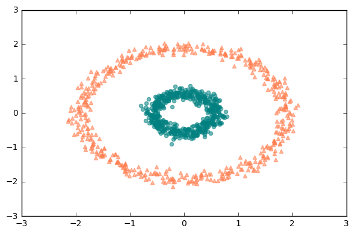

```python
# Plotting using matplotlib.pyplot, to take a first glance at how our dataset is distributed


import matplotlib.pyplot as plt

plt.scatter(X_std_hack.T[y == 0, 0], X_std_hack.T[y == 0, 1], color='coral', marker='^',  alpha= 0.54321)
plt.scatter(X_std_hack.T[y == 1, 0], X_std_hack.T[y == 1, 1], color='teal', marker='o', alpha= 0.54321)

plt.tight_layout()
plt.show()
```

## Step_2: Find covariance matrix, of the normalized dataset X_std_hack

### COV_MATRIX:

a d×d matrix where each element represents the covariance between two features.

### Goal: acquire eigenv*

## 2a. Calculate Covariance Matrix: One way,

```python
import numpy as np

mean_vec = np.mean(X_std_hack.T, axis=0)

N = X_std_hack.shape[1]                # X_std_hack.shape = (2,1000), thus N = 1000 is what we need for the scaling
scaling_factor = 1 / (N-1)             # 1/N-1
COV_MATRIX =  scaling_factor * (X_std_hack.T - mean_vec).T.dot((X_std_hack.T - mean_vec))

print("COV_MATRIX.shape: ", COV_MATRIX.shape, "\n")
print("COV_MATRIX\n", COV_MATRIX )
```

```
COV_MATRIX.shape:  (2, 2)

COV_MATRIX
 [[ 1.001001    0.00694385]
 [ 0.00694385  1.001001  ]]
```

## 2b. Calculate Covariance Matrix: or another (way)

```python
COV_MATRIX_hack = np.cov(X_std_hack)
COV_MATRIX_hack.shape

print("COV_MATRIX_hack.shape: ", COV_MATRIX_hack.shape, "\n")
print("COV_MATRIX_hack\n", COV_MATRIX_hack )

#looks good; symmetrical as we expected, since it occurs by multi of X X.T
```

```
COV_MATRIX_hack.shape:  (2, 2)

COV_MATRIX_hack
 [[ 1.001001    0.00694385]
 [ 0.00694385  1.001001  ]]
```

## 3. Eigendecomposition on the covariance matrix

```python
eig_vals, eig_vecs = np.linalg.eig(COV_MATRIX_hack)

print('Eigenvectors \n', eig_vecs)
print('\nEigenvalues \n', eig_vals)
```

```
Eigenvectors
 [[ 0.70710678 -0.70710678]
 [ 0.70710678  0.70710678]]

Eigenvalues
 [ 1.00794485  0.99405715]
```

#### OPTIONAL AT THIS POINT: Perform SVD on COV_MATRIX

```python
# https://docs.scipy.org/doc/numpy/reference/generated/numpy.linalg.svd.html
U, s, V = np.linalg.svd(COV_MATRIX_hack)

# Where:
# U:
# s: np.diag(S), an array with just the elements of the diagonal of the S matrix. aka the eigenvalues since COV_MATRIX
# V:
print('u.shape:', U.shape, "type(U):", type(U))
print('s.shape:', s.shape,  "  type(s):", type(s))
print('v.shape:', V.shape, "type(V):", type(V))
```

```
u.shape: (2, 2) type(U): <class 'numpy.ndarray'>
s.shape: (2,)   type(s): <class 'numpy.ndarray'>
v.shape: (2, 2) type(V): <class 'numpy.ndarray'>
```

## Sorting Eigenv* pairs in descending order:

#### OPTIONAL FOR THIS DATASET: because k = d = 2, and we'd most likely choose to plot on 2D

```python
eig_pairs = [(eig_vals[i], eig_vecs[:,i]) for i in range(len(eig_vals))]
eig_pairs.sort(key=lambda x: x[0], reverse=True)

eig_pairs
```

```
[(1.0079448492840934, array([ 0.70710678,  0.70710678])),
 (0.99405715271790829, array([-0.70710678,  0.70710678]))]
```

```python
#The eigvals in descending order:'
list(enumerate([i[0] for i in eig_pairs], start=1))
```

```
[(1, 1.0079448492840934), (2, 0.99405715271790829)]
```

## Choosing k, number of eigenv* to project dataset to:

#### Explained variance metric, can be calculated by eigenvalues and highlight the variance attributed (cumulative measure) to each eigenv

#### The k eigenv* chosen in this step will dictate W matrix shape, which will be (k,k)

```python
tot = sum(eig_vals)
var_exp = [(i / tot)*100 for i in sorted(eig_vals, reverse=True)]
cum_var_exp = np.cumsum(var_exp)

print("Variance attributed to first eigenvector:", cum_var_exp[0] )
print("Variance attributed to first two eigenvectors:", cum_var_exp[1] )


# Pretty rational since we only have two anyway.
```

```
Variance attributed to first eigenvector: 50.3468452217
Variance attributed to first two eigenvectors: 100.0
```

# Creating the W matrix, aka: the Projectionizer

#### Prrojectionizer, as in, once our dataset is multiplied with W, it will be projected into the new k-dimensional subspace

#### W.shape = d x k

```python
k = 2
W = np.hstack((eig_pairs[0][1].reshape(k,1), eig_pairs[1][1].reshape(k,1)))

print('Matrix W:\n', W)
print('W.shape', W.shape)
print('X_std_hack.shape', X_std_hack.shape)
```

```
Matrix W:
 [[ 0.70710678 -0.70710678]
 [ 0.70710678  0.70710678]]
W.shape (2, 2)
X_std_hack.shape (2, 1000)
```

## Y = X.dot(W) , equivalent to W.T.dot(X)

```python
k = 2
if X_std_hack.shape[1] == k:
    Y = X_std_hack.dot(W)
else:
    Y = W.dot(X_std_hack)

print(Y.shape)
```

```
(2, 1000)
```

## Plot data after PCA:

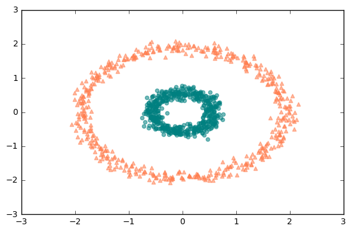

```python
# Plotting using matplotlib.pyplot, to take a first glance at how our dataset is distributed


import matplotlib.pyplot as plt

plt.scatter(Y.T[y == 0, 0], Y.T[y == 0, 1], color='coral', marker='^',  alpha= 0.54321)
plt.scatter(Y.T[y == 1, 0], Y.T[y == 1, 1], color='teal', marker='o', alpha= 0.54321)

plt.tight_layout()
plt.show()
```

## (ii) PPCA:

```python
#!/usr/bin/env python3

# DEPENDENCIES:
import numpy as np
from sklearn.metrics import mean_squared_error
import random
# from sklearn.datasets import make_circles

# STEP_0:
# Generate artificial dataset according to instructions, using the scikit-learn snippet below:
# Let X, be our initial dataset

# NOTE:
# The artificial dataset is already centered to 0, upon generation
from sklearn.datasets import make_circles
X, y = make_circles(n_samples = 1000, factor = 0.3, noise = 0.05)

row1 = X.T[0]
row2 = X.T[1]

# 2. Find the SUM of all elements in the  row vector &
# 3. DEVIDE by the number of elements in the vector. SInce the array is 1-D, vector.size will do.

mean_row1 = np.sum(row1)/row1.size
mean_row2 = np.sum(row2)/row2.size

# Creating the mean vector of X:
X_mean_vector = np.mat([mean_row1, mean_row2]).T #mean_vector.shape (2,1)
X_mean_MATRIX = np.kron(np.ones((1,1000)),X_mean_vector) #mean_matrix.shape 2x1000, X.T.shape(2x1000)
X_minus_mean_MATRIX = X.T - X_mean_MATRIX #we have taken the transpose here, so that X_minus_mean_MATRIX.shape is ([2,1000])

D = 2
N = 1000
k = 2


W_random = np.random.rand(D,k)
sigma_2 = random.uniform(0,1)
counter = 0
while True:

    # Step_2:  EM
    # initialize iteration counter:
    counter = counter + 1
    print(counter)
    # Create I matrix , I.shape = (k,k):
    PPCA_I_matrix =  np.matrix(np.eye((k)))

    # E_STEP:
    # - Create random W:

    #Calculate M:
    M = W_random.T.dot(W_random) + sigma_2*PPCA_I_matrix

    # Calculate E_zn matrix
    # Take each sample as array stored in lists as :
    # (i) vertical vector (2,1)
    # (ii) horizontal vector (1,2), which will be the Zn.T vectors
    E_zn =  (M.I.dot(W_random.T)).dot(X_minus_mean_MATRIX)
    vertical_Zn_vectors = [i.T for i in E_zn.T]
    horizontal_Zn_vectors = [i for i in E_zn.T]


    #We can calculate straight up sum(E_znznT) without iterating, like so:

    #sum_E_znznT = sigma_2*M.I + E_zn.dot(E_zn.T) # reminder E_zn is a matrix (2,1000), so the sum_EznznT.shape = (2,2)

    #or,
    #we could make one by one the 1000 product pairs, store in a list, then get sum like so:
    E_znznT_vectors_list = [sigma_2*M.I + vertical_Zn_vectors[i]*horizontal_Zn_vectors[i] for i in range(len(vertical_Zn_vectors))]
    alt_sum_E_znznT = sum(E_znznT_vectors_list)


    # M_STEP:

    # Calculate W_new:
    # W_new_part1 = Σ {(x1 - mean) E_zn.T }
    vertical_X_minus_mean_vectors =  [i.T for i in X_minus_mean_MATRIX.T]

    W_new_part1 = sum([vertical_X_minus_mean_vectors[i]*horizontal_Zn_vectors[i] for i in range(len(horizontal_Zn_vectors))])
    W_new_part2 = alt_sum_E_znznT.I

    W_new = W_new_part1.dot(W_new_part2)
    W_success_metric = (mean_squared_error(W_random, W_new))**0.5


    # Calculate sigma_2_new:

    # sigma_2_new = 1/ND * {A -2B + C}
    #             = 1/ND * {sum(ai) -2 sum(bi) + sum(ci)}               =

    # A:
    # A = sum(norms_list) = sum([np.linalg.norm(i) for i in X_minus_mean_MATRIX.T])
    A = sum([np.linalg.norm(i) for i in X_minus_mean_MATRIX.T])


    # B:
    # B = E_Zn.T*W_new.T(x - mean)
    # This sum{..} ends up to a 0D matrix with 1 scalar inside
    # So we use [0,0] in the end of the list comprhnsion to unpack just the value
    B_for_sum = [horizontal_Zn_vectors[i]*W_new.T*vertical_X_minus_mean_vectors[i] for i in range(len(horizontal_Zn_vectors))]
    B = (sum(B_for_sum))[0,0]


    # C:
    # C = np.trace(sum(EznznT W_new.TW_new))

    # We could calculate C iteratively like so:
    # Create list "to_be_summed_and_traced", which contains N kxk matrices,
    # calculated for each Zn vector:

    to_be_summed_and_traced = [E_znznT_vectors_list[i]*W_new.T*W_new for i in range(len(E_znznT_vectors_list))]
    C = np.trace(sum(to_be_summed_and_traced))


    # Now to calculate sigma_2_new all we have to do is ombine the A,B,C tgether acording to the formula:
    # sigma_2_new = 1/ND * {A -2B + C}
    ND_factor  = 1/N*D
    sigma_2_new = ND_factor*(A - 2*B + C)
    print("W_success_metric",W_success_metric)
    print("abs(sigma_2, sigma_2_new):", abs(sigma_2 - sigma_2_new))

    if W_success_metric < 0.00000001 and abs(sigma_2 - sigma_2_new)<0.00000001:   # 10**(-8)

        print("W_new:, ", W_new, "sigma_2_new", sigma_2_new, "Number of iterations:", counter)
        break

    else:
        W_random = W_new
        sigma_2  = sigma_2_new
```

```
1
W_success_metric 0.306205844954
abs(sigma_2, sigma_2_new): 0.724332876122
2
W_success_metric 0.287271250606
abs(sigma_2, sigma_2_new): 0.267753349519
3
W_success_metric 0.0765012241457
abs(sigma_2, sigma_2_new): 0.0511872428455
4
W_success_metric 0.0167858887556
abs(sigma_2, sigma_2_new): 0.00337718225025
5
W_success_metric 0.00352646198148
abs(sigma_2, sigma_2_new): 0.000152055844765
6
W_success_metric 0.000738707623297
abs(sigma_2, sigma_2_new): 6.67850192482e-06
7
W_success_metric 0.000154727089969
abs(sigma_2, sigma_2_new): 2.93016609643e-07
8
W_success_metric 3.24097628374e-05
abs(sigma_2, sigma_2_new): 1.28564205948e-08
9
W_success_metric 6.78896654196e-06
abs(sigma_2, sigma_2_new): 5.64136071191e-10
10
W_success_metric 1.42216533116e-06
abs(sigma_2, sigma_2_new): 2.47561970923e-11
11
W_success_metric 2.97930723306e-07
abs(sigma_2, sigma_2_new): 1.08624220729e-12
12
W_success_metric 6.24165059936e-08
abs(sigma_2, sigma_2_new): 4.79616346638e-14
13
W_success_metric 1.30768381415e-08
abs(sigma_2, sigma_2_new): 1.99840144433e-15
14
W_success_metric 2.7398409077e-09
abs(sigma_2, sigma_2_new): 2.22044604925e-16
W_new:,  [[  2.35771574e-10   8.25587273e-10]
 [  8.67176430e-10   7.87766447e-10]] sigma_2_new 1.30211535873 Number of iterations: 14
```

## Performing SVD on W_new:

```python
U, s, V = np.linalg.svd(W_new)
U
```

```
matrix([[-0.57080327, -0.82108686],
        [-0.82108686,  0.57080327]])
```

## Using U matrix to project our dataset:

## Y = U.T.dot(X_minus_mean_MATRIX)

```python
Y_ppca = U.T.dot(X_minus_mean_MATRIX)
Y_ppca.shape
```

```
(2, 1000)
```

## Plotting the data after PPCA:

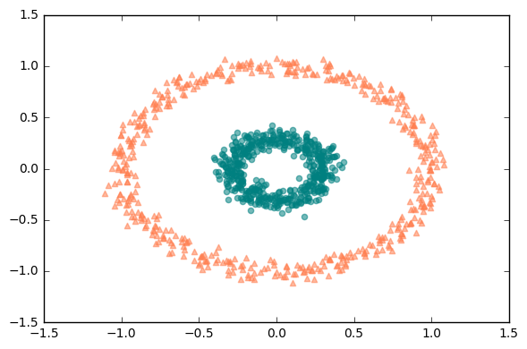

```python
import matplotlib.pyplot as plt

plt.scatter(Y_ppca.T[y == 0, 0], Y_ppca.T[y == 0, 1], color='coral', marker='^', alpha= 0.54321)
plt.scatter(Y_ppca.T[y == 1, 0], Y_ppca.T[y == 1, 1], color='teal', marker='o', alpha= 0.54321)

plt.tight_layout()
plt.show()
```

The dataset still cannot be linearly separated after the PPCA approach.